# Blue Nile Diamonds Analysis

Group 8: Caroline Bush, Humaira Halim, Leah Hogenmiller, Tatev Kyosababyan

### STAT6021 - Linear Models for Data Science

### Section 1

The diamond is a staple gemstone in jewelry and other luxury items such that there exists a multitude of prospective buyers, each with a particular budget. In particular, it is a rite of passage within the wedding scene to pick the perfect diamond for one’s wedding band. Guiding these buyers through the tradeoffs that allow them to purchase a high-quality diamond while adhering to their budget requires comprehensive knowledge of how the characteristics of a diamond influence its price. In particular, this report describes how the diamond’s carat, cut, color, and clarity each affect price based on the diamonds that are part of Blue Nile’s inventory.  
A diamond’s carat, also known as its weight, is one consideration for the prospective buyer and an important indicator of a diamond’s price. Large diamonds are rarer than smaller diamonds such that most diamonds on the market are less than two carats. Due to the scarcity of high-carat diamonds, these gemstones become increasingly more expensive with size: for every 1% increase in diamond carat, the price increases by 2%. Carat alone does not dictate a diamond’s price, however: cut, color, and clarity also contribute to a diamond’s overall quality. Smaller carat diamonds are more likely to have high-quality cut, color, and clarity than larger gemstones. Thus, it is imperative to understand how these characteristics interact with carat to determine a diamond’s total price.  
The cut of a diamond refers to how well-proportioned the dimensions of the gemstone are, as these properties determine how light moves and generate the characteristic sparkle that makes diamonds so attractive. Diamonds with higher cut grades appear more brilliant and are thought to be priced higher than diamonds of a lower cut grade. Indeed, these diamonds can reach incredibly lofty prices for their carat. Opting for a lower cut grade may reduce the price of a diamond, but that largely depends upon the gemstone’s other characteristics. When considering cut alone, there are diamonds of more modest cut grades with prices that exceed those of higher-quality cuts. Nevertheless, prospective buyers working within a budget are often encouraged to sacrifice carat in favor of a higher-quality cut. Whether this strategy helps these buyers stay within budget, however, demands consideration of diamond color and clarity.  
After cut, a diamond’s color is the next metric of its quality. Colorless diamonds are the most prized and also the rarest, which makes them more expensive than diamonds with more color. As color is more noticeable in diamonds above one carat, the difference in price across color grades becomes much greater at higher carats. Prospective buyers considering smaller diamonds are therefore less likely to see dramatic differences in price across color grades. Instead, the prices of these diamonds are more strongly influenced by their cut and clarity.  
Clarity is the final metric of diamond quality included in this report, and is scaled according to the number and severity of the natural imperfections that occur in all gemstones. Diamonds with none or only microscopic surface flaws are incredibly rare, and can be among the most expensive diamonds on the market. Many imperfections are invisible to the naked eye, however, and can be hidden by a high-quality cut, particularly among smaller diamonds. As a result, clarity plays only a minor role in determining the price of most diamonds on the market, regardless of size.  
A diamond’s carat, cut, color, and clarity are among the most important factors influencing price. Carat is the strongest determinant of price, with higher-carat diamonds becoming increasingly more expensive regardless of their cut, color, or clarity. Among diamonds of similar carat, however, cut plays a large role in dictating price. Diamonds of a high cut quality tend to have higher prices than those of lower quality cut grades such that opting for a lower-carat diamond in favor of a better cut may not necessarily reduce the price. Color and clarity are similar in that colorless and unblemished diamonds are more expensive than those of lower color and clarity grades for a given carat. However, this difference is minimal among most diamonds on the market due to their small size. These relationships between price and the carat, cut, color, and clarity of a diamond are important to consider when guiding prospective buyers towards a high-quality diamond within a particular budget.

### Section 2

Blue Nile’s inventory features over 1,000 diamonds of varying quality as determined by the carat, cut, color, and clarity. These four qualities are among the most important determinants of a diamond’s price. Using data on the Blue Nile inventory, we have investigated how specifically these metrics of diamond quality affect the price.

#### Carat

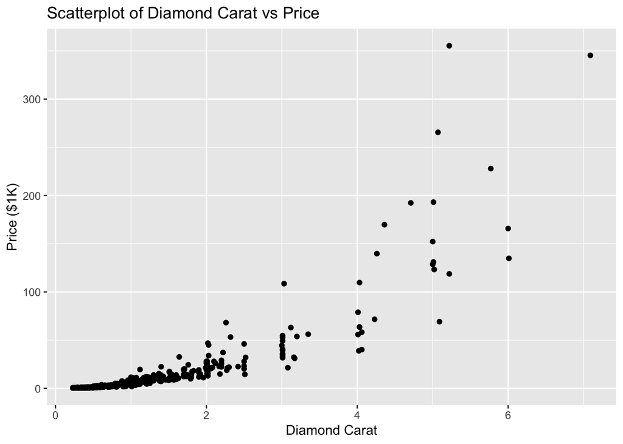

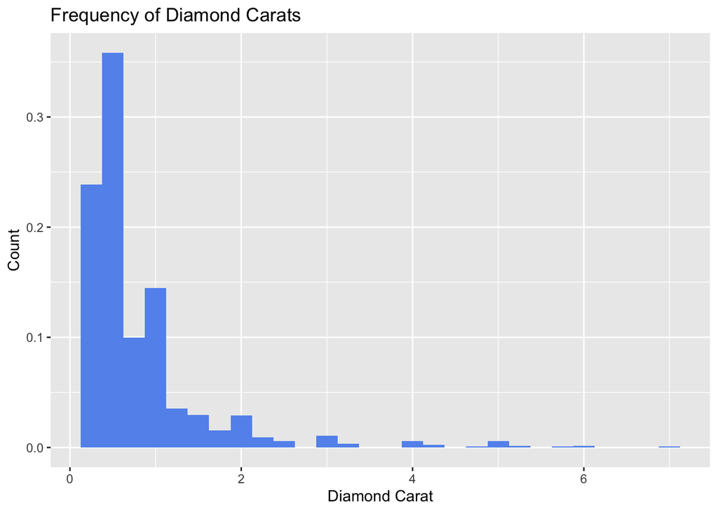

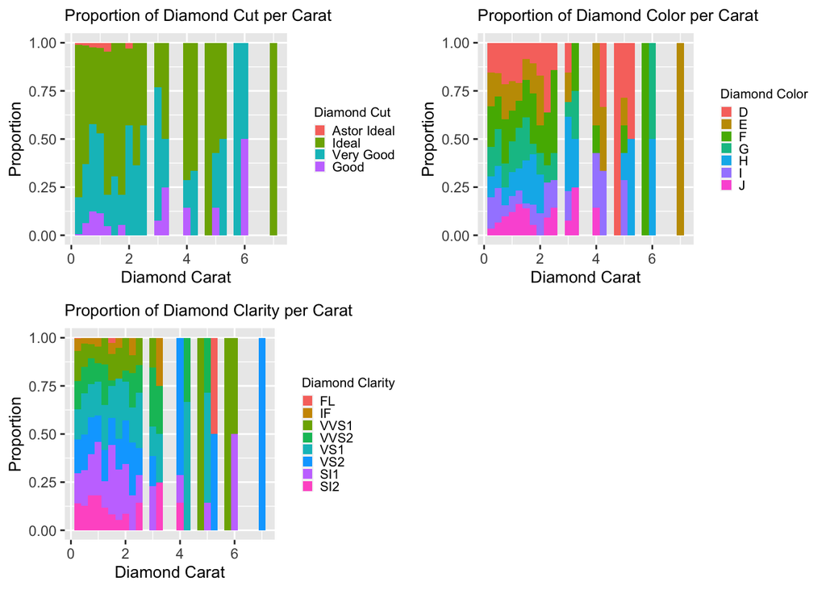

Blue Nile recommends selecting a slightly smaller carat in favor of, spending more on a good cut, and using shape to mask deficiencies in color and clarity to purchase the best diamond possible for a given price. Whether these compromises actually reduce the total price of the diamond, however, remains to be verified.

#### Cut

A diamond’s cut determines the amount of light that is reflected out of it, generating the eye-catching brilliance, fire, and sparkle that contribute to a diamond’s overall beauty. Although most of the public considers carat the primary factor dictating a diamond’s price, Blue Nile asserts that the cut of a diamond can have the strongest influence. Prospective buyers are also encouraged to prioritize a superior cut over a higher carat diamond when shopping within a budget.  
There are six grades of diamond cuts, listed below in descending order of quality as measured by the amount of light that the diamond reflects: Astor by Blue Nile™ or Ideal (the top ~3% of diamond cut quality), Very Good (the top ~15% of diamond cut quality), Good (the top ~25% of diamond cut quality), Fair, and Poor. All Blue Nile diamonds are graded by the Gemological Institute of America (GIA), and those of the Astor by Blue Nile™ cut grade are additionally certified for light performance by GemEx®. The latter two grades (Fair and Poor) are not sold by Blue Nile, and so are excluded from this report.  
The majority of diamonds in the Blue Nile inventory are Ideal or Very Good cut grades, representing 60.87% and 31.47% of diamonds, respectively. The highest quality diamonds, Astor by Blue Nile™, represent only 1.65% of diamonds in stock.

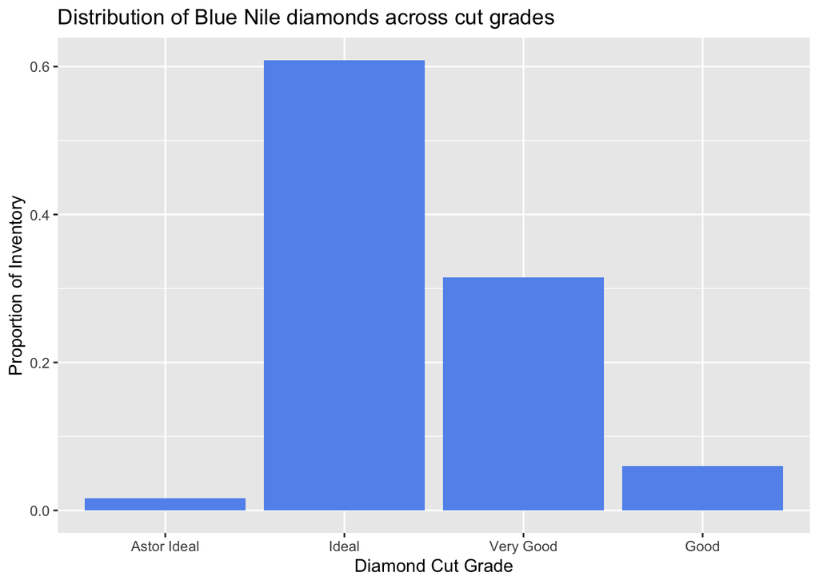

The price of a Blue Nile diamond varies widely within each cut grade, such that it is difficult to glean meaningful insights when all of the data is plotted on the same set of axes (see below):

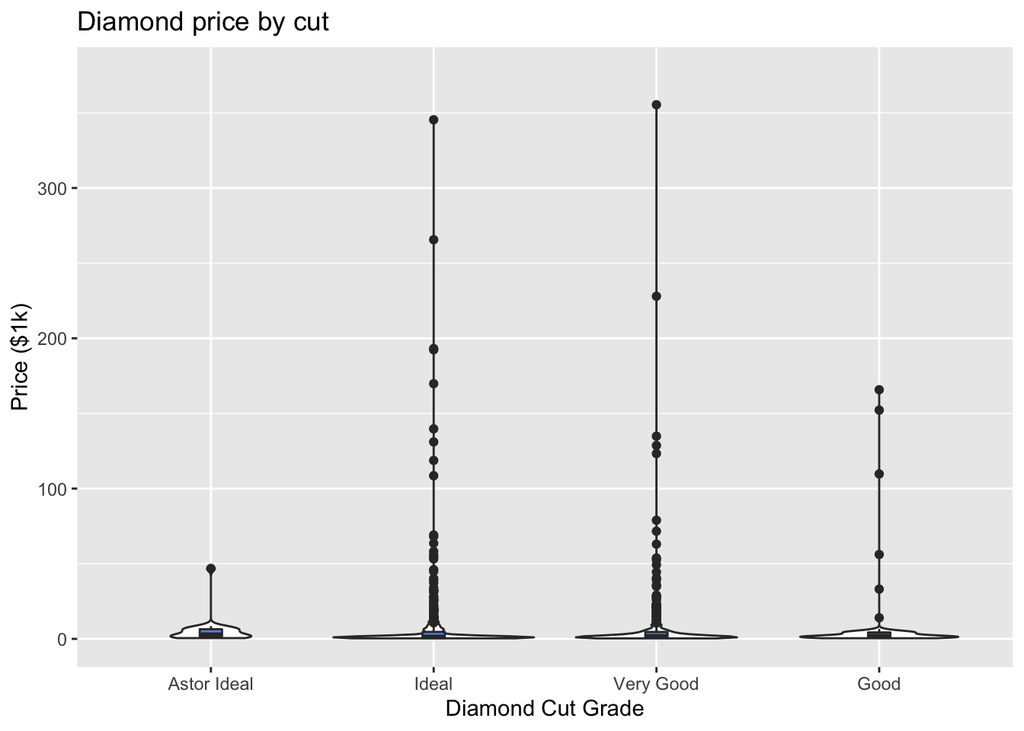

To more effectively visualize the relationship between a diamond’s price and cut, diamonds with prices above $10.6k (outliers in this data set by IQR, $n = 143$) will be graphed separately. The broad trends observed in these graphs are generally consistent between non-outliers and outliers, however, so they will be discussed as one. For all figures, diamonds with prices $< \$10,600$ are graphed on the left, and diamonds with prices $\geq \$10,600$ are graphed on the right.  
A combination boxplot and violin plot were used to gain a general knowledge of diamond prices within and between each cut grade. As expected, diamonds of the Astor by Blue Nile™ cut grade have a higher median price compared to the other cut grades in the Blue Nile inventory. The prices of these high-cut quality diamonds are also evenly distributed across its range. Diamonds of the Ideal and Very Good cut grades, however, are less consistent in their prices. The highest prices in these intermediate cut grades exceed that of the most expensive Astor by Blue Nile™ diamond, but most diamonds in these cut grades are priced at or below the median value. No diamonds of the Good cut grade quite reach these extreme values, but they also exhibit an appreciable range of prices. It is interesting to note that the median price increases with lower-quality cut grades (excluding Astor by Blue Nile™), despite Blue Nile’s claims that cut is a major determinant of price.

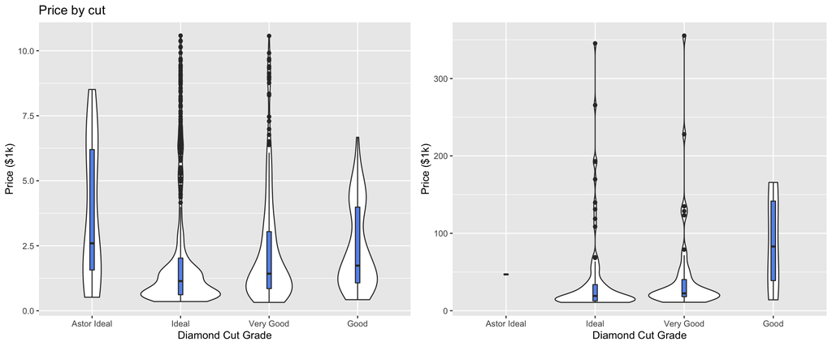

Cut grade is not the sole determinant of a diamond’s price: carat is often viewed as the primary factor influencing price. The scatterplots below show the relationship between price and carat, while distinguishing between the different cut grades. A diamond’s price increases with carat, and larger carat diamonds are increasingly more expensive. This trend holds regardless of the diamond’s cut, and complies with the claims made by Blue Nile on their website. For a given carat, diamonds of a higher grade cut also tend to be more expensive, in agreement with Blue Nile’s assertion that cut is a key determinant of a diamond’s price. This trend appears to be exaggerated for higher carat diamonds, albeit imperfectly.

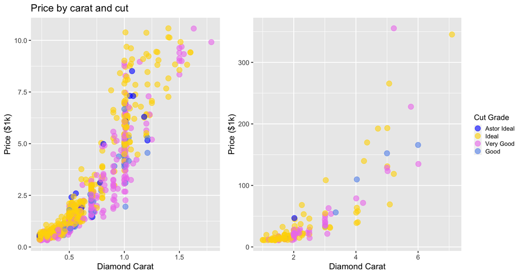

Deviations from the general trends outlined above may be explained by other factors contributing to a diamond’s overall value, namely their color and clarity. While these attributes are discussed in greater depth below, here we examine how these attributes are distributed within each cut grade.  
Diamonds of the highest-quality color grades (G and above) appear approximately evenly represented among Ideal and Very Good cut grade diamonds. Astor by Blue Nile™ diamonds are most frequently in the F color grade, but this skew may be a by-product of a lower sample size ($n = 20$). Similarly, an unexpectedly high proportion of Good cut grade diamonds have the highest color ranking, but this may be due to the lower sample size ($n = 73$).  
The highest clarity diamonds are extremely rare such that they make up only a small proportion of the diamonds in each cut grade, including Astor by Blue Nile™. Of the clarity grades that are in the Blue Nile inventory, the proportional representation of the higher clarity grades generally declines with the cut grade as the distribution of clarity grades shifts somewhat towards lower grades.

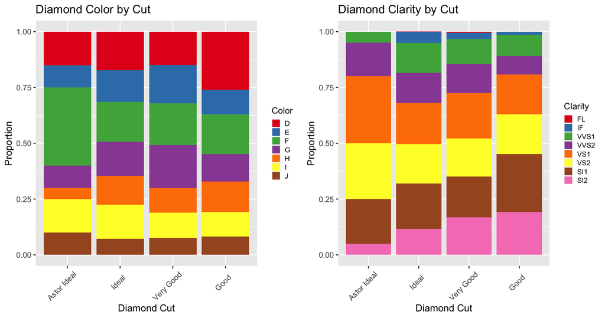

#### Color

Blue Nile claims the diamond’s color is the second most important factor, with the ideal diamond being nearly colorless. Lesser color is associated with a higher grade (assigned a letter D-Z). Diamond prices increase with an alphabetical order. Finding a diamond without any color (aka a D-F grade) is incredibly rare, presumably making it pricier. In contrast, near-colorless diamonds receive a grade between G-H or I-J. Lastly, faintly colored diamonds would receive a K, which would be the least expensive grade. Blue Nile does not produce diamonds past a K grade as per their quality standards.  
Given that color is a categorical variable, we will be visualizing the relationship between price and color using boxplots in order to see the range of prices by color. Price is also enumerated by the $1000’s for easier readability.

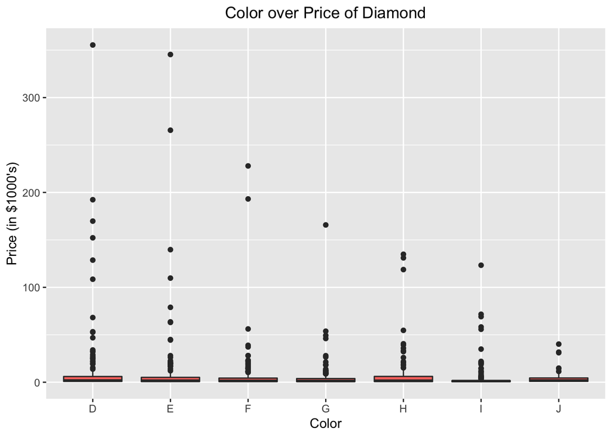

The large quantity of outliers makes it difficult to see the boxplots themselves, but the extreme range of outliers is informative itself, with the maximum values decreasing steadily going down the alphabet. This is consistent with Blue Nile’s claim that lesser color+higher grades are associated with higher prices, and lower grades being cheaper.  
Beyond the simple relationship between color and price, Blue Nile also claims that color is more visible in larger diamonds. Therefore, they claim color matters more when going over 1 carat whereas diamonds under 1 carat are more acceptable for an I-K grade. To take this relationship into account, we can also visualize the relationship between all three by creating a scatter plot of carat vs. price and coloring each point by its diamond color.

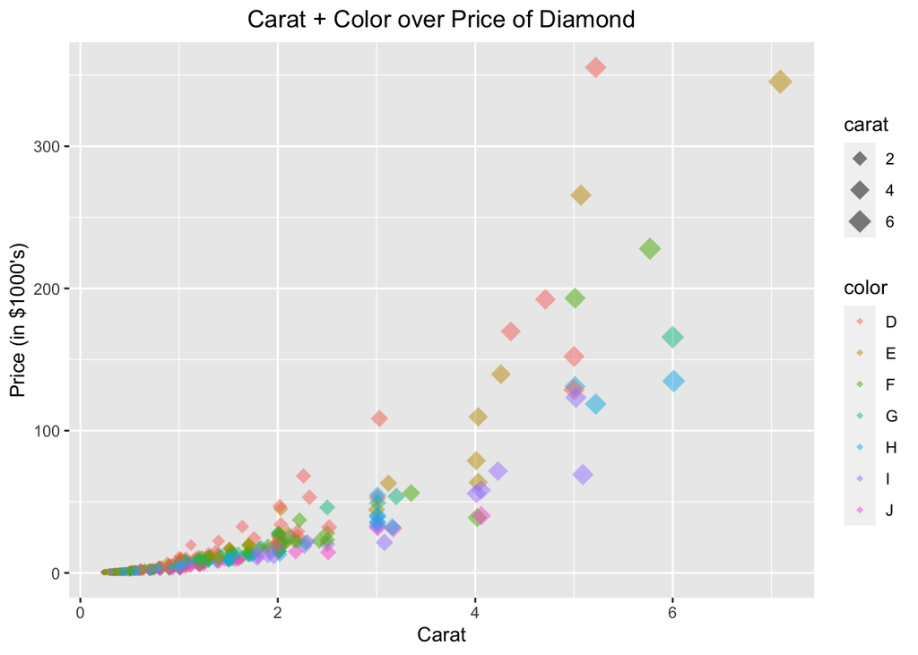

#### Clarity

Diamonds are made underground through enormous pressure and heat, which means that natural surface flaws are unavoidable. Diamond clarity is the assessment of small imperfections on the surface and within the stone. The flaws on the surface of a diamond are called blemishes; these do not affect the appearance of the diamonds to the naked eye. These flaws are also considered as “internal characteristics” since they give the diamond its own character and uniqueness.  
Diamond clarity spans 6 categories with a total of 11 clarity grades. The lowest grades are I1, I2, and I3, which are the Included Diamonds–these have visible imperfections likely to affect the beauty of the diamond. Next there are the SI1, and SI2, the Slightly Included diamonds, where the inclusions are noticeable at 10x magnification only. The Very Slightly Included diamonds have minor inclusions either difficult (VS1) or somewhat easy (VS2) to see at 10x magnification. These are the most popular ones at Blue Nile, according to the website. VVS1 and VVS2 represent the Very Very Slightly Included category of the diamond clarity grade, where even the trained eye cannot spot the imperfections under 10x magnification. IF stands for the Internally Flawless diamonds which can have some small surface blemishes visible under a microscope. And the highest grade for diamond clarity is the Flawless diamonds (F), which has no internal or external characteristics. The latter is extremely rare, and can occur with only 1% of the diamonds.  
The Blue Nile claims that although clarity impacts the appearance of a diamond, a high clarity grade does not guarantee more sparkle or avoidance of imperfections. They suggest selecting a diamond with inclusions that can’t be seen through the crown without magnification as opposed to choosing one with the highest clarity grade. The majority of diamond clarity levels in the Blue Nile diamonds dataset are identified as “Very Slightly Included” or “Slightly Included”, making up about 70% of the entire dataset. Furthermore, the Included clarity level diamonds are not a part of this dataset.

[figure not shown]

Generally, diamonds with the fewest and smallest blemishes are priced higher, as we can see in the graph below.

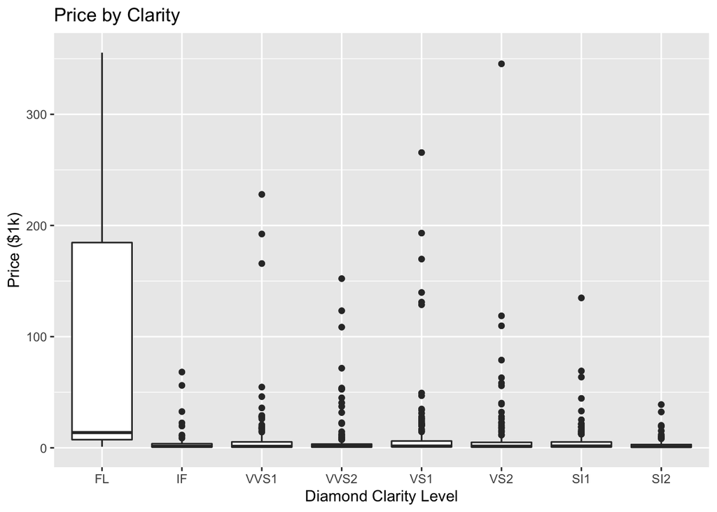

However, if we take a look at the datapoints of only flawless diamonds, which is the highest grade for clarity, we will see that the clarity level does not necessarily impact the price as much as the other characteristics of a diamond.

```
##     carat clarity color       cut  price
## 106  1.40      FL     F Very Good  13733
## 355  0.29      FL     D     Ideal   1072
## 795  5.22      FL     D Very Good 355403
```

### Section 3

[figure not shown]

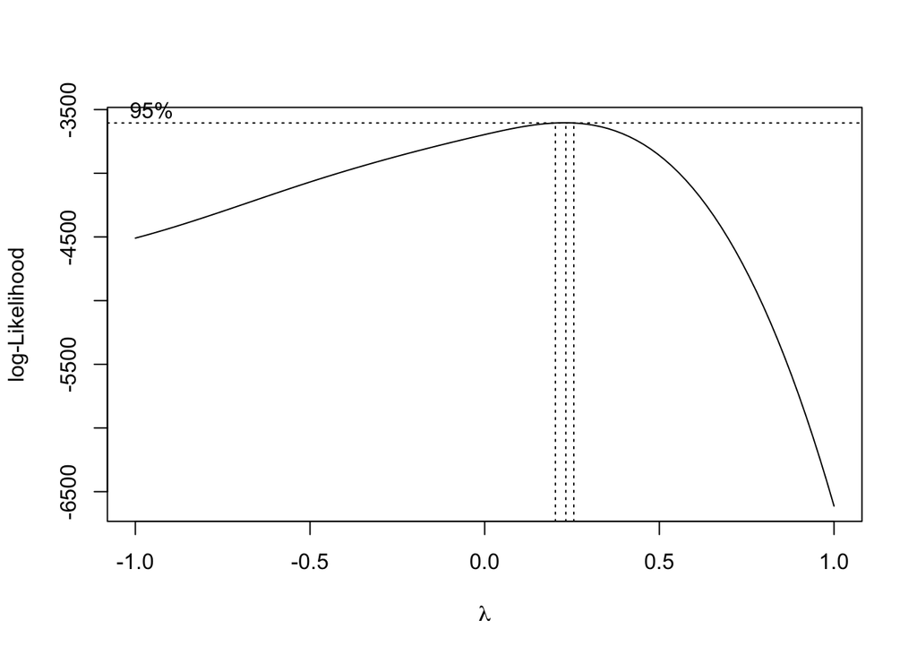

After the log transformation on the response variable, the variance among the residuals is more consistent, and the values are more evenly distributed around zero. However, as both the scatterplot and the residual plot show a nonlinear relationship, the assumptions of simple linear regression are still not being met.

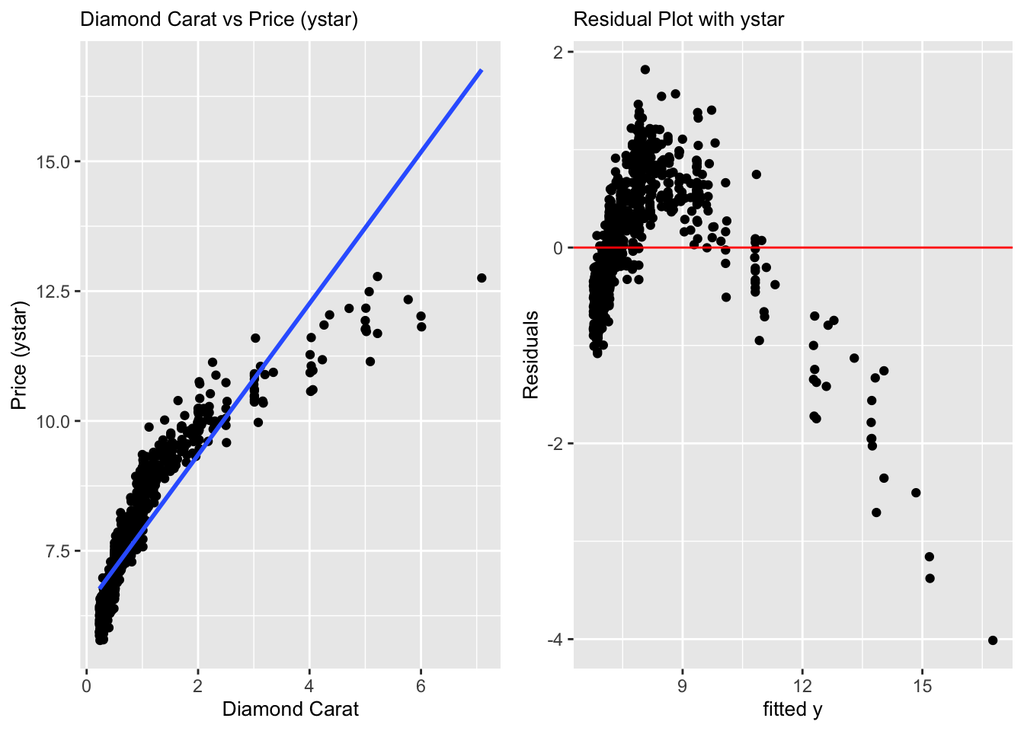

A log transformation of the predictor variable, carat, will be performed in order to fix the nonlinear relationship

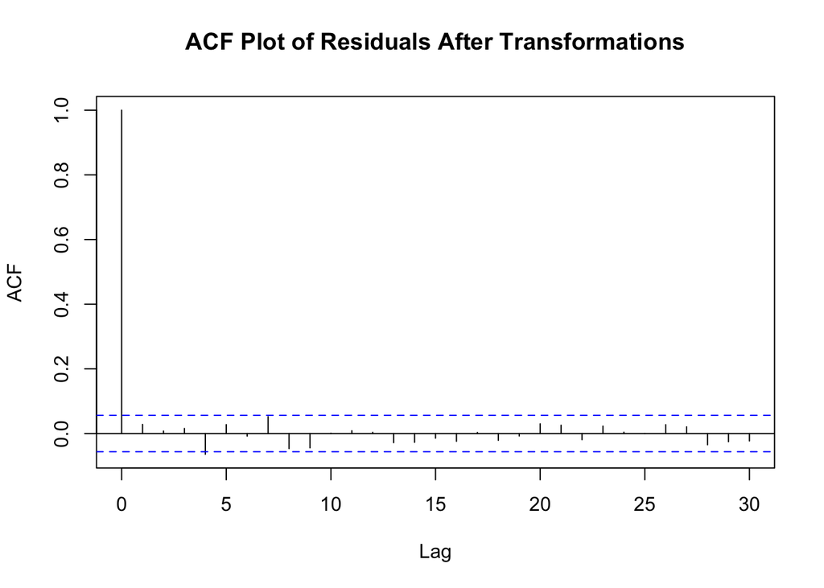

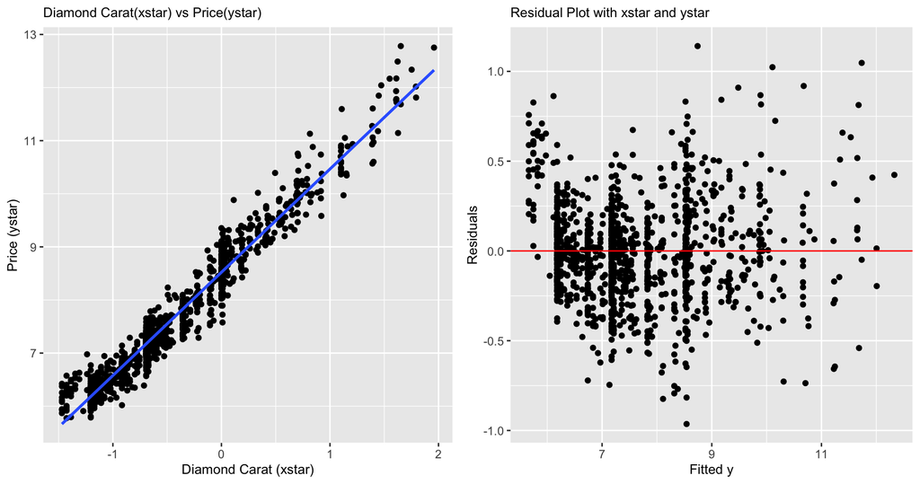

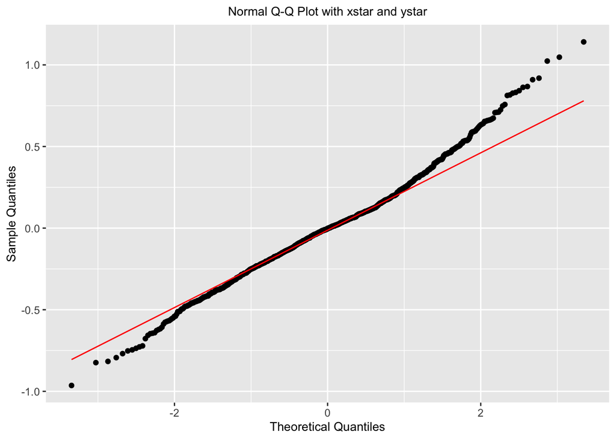